# R mini-course: week 3 notes

timothy leffel june2/2017

In these notes we’ll be looking at some sample data from the General Social Survey (GSS), a survey measuring American opinion on a variety of issues. The survey has been conducted bi-annually by NORC for many years. Many thanks to Ben Schapiro for prepping this stuff! It’s very cool data, and quite good for illustrating many common data wrangling tasks. After some discussion about planning in Sections 1-2, we start writing actual code to manipulate the data in Section 3. Feel free to skip directly to Section 3 if you just want to practice coding.

**note** on the datasets: we have sample data from three years: 2012, 2014, and 2016. You can find the corresponding datasets [here (2012)](http://lefft.xyz/r_minicourse/week3_materials/datasets/gss_2012_test.csv), [here (2014)](http://lefft.xyz/r_minicourse/week3_materials/datasets/gss_2014_test.csv), and [here (2016)](http://lefft.xyz/r_minicourse/week3_materials/datasets/gss_2016_test.csv). In these notes we’ll look just at the 2016 data, but there’s so much more we could look at if we merged all three files. There are a couple of exercises below that will involve doing exactly that. But in case you just want to practice with the combined data, here’s [a link](http://lefft.xyz/r_minicourse/week3_materials/datasets/gss_complete_test.csv) to a file with all three years together. Or just get [everything as a .zip archive](http://lefft.xyz/r_minicourse/week3_materials.zip), including a partial codebook and a script.

### 0. for next week

Keep your dataset in mind when working through these notes. Then try to make a list of things you want to do to the data. For example: recode or plot some of the variables, maybe reshape it with a `melt()` command, make a frequency table for a couple variables of interest, etc.

Try to make the list manageable – identify maybe five operations total. Then next week, we’ll implement those operations and build a nice lil output document from an R-Markdown file (which is just a fancy type of R script, basically).

### 1. getting the data and defining the problem

We want to see if the wording of a question has an effect on how people (identified by an `id`) respond to it. The (categorical) grouping variable that determines what kind of wording they got is `form`, which takes the values 1 or 2 (which aren’t categorical – we’ll recode them so that they are).

We have three questions with alternative wordings, which we’d like to investigate (manipulated between-subjects, across the levels of `form`). The questions of interest are:

> We are faced with many problems in this country, none of which can be solved easily or inexpensively. I’m going to name some of these problems, and for each one I’d like you to tell me whether you think we’re spending too much money on it, too little money, or about the right amount…  
> **[A]re we spending too much, too little, or about the right amount on (ITEM)?**

where **(ITEM)** is one of the following:

- **`natcity`**: *[A]re we spending too much, too little, or about the right amount on…*
  - …SOLVING PROBLEMS OF BIG CITIES (if `form==1`, response is in `natcity`)
  - …ASSISTANCE TO BIG CITIES (if `form==2`, response is in `natcityy`)
- **`natrace`**: *[A]re we spending too much, too little, or about the right amount on…*
  - …IMPROVING THE CONDITIONS OF BLACKS (if `form==1`, response is in `natrace`)
  - …ASSISTANCE TO BLACKS (if `form==2`, response is in `natracey`)
- **`natfare`**: *[A]re we spending too much, too little, or about the right amount on…*
  - …WELFARE (if `form==1`, response is in `natfare`)
  - …ASSISTANCE TO THE POOR (if `form==2`, response is in `natfarey`)

*An important question*: should we be interested in variation across `form` for each individual questionnaire item, or can we consider each question an “item” in the sense that a “trial” instantiating it can appear in multiple “conditions” (here `form==1` or `form==2`)? This really depends on our purpose, which here is to demonstrate how to manipulate data. In other words, the question is important if our goals are scientific, but not so much presently…

Since the `form==2` questions for `nat*` all involve the same wording – namely “assistance to …” – maybe it makes sense to consider `form==1` an indication of a “variable” that we could call something like *non-uniform wording*. Or maybe a slightly better option would be to view `form` as encoding an abstract variable describable as (roughly!) “contains the word *assistance* in the questionnaire text.” Viewed this way, instead of having $n=2867$ observations of three different outcome variables, we would now have $n=2867\times3=8601$ observations of a single outcome variable.

So what we want to do is to investigate relationships between item responses and other characteristics of the data that responses are “nested” inside of: which of the three items it is; which wording the respondent got (form 1 or form 2); demographic characteristics of the respondents; etc.

**a note on the importance of domain-specific knowledge**: One could certainly argue that the notion of a single, underlying “difference in wording” between the `nat*` and `nat*y` variables (in our subset of the GSS) isn’t very well motivated. It’s not like the `nat*` versions all have more words than their `nat*t` counterparts, for example…These are the types of issues where domain-specific knowledge/expertise is really important. Since I’m not super well-versed in the GSS, my strategy might not be the best one for the particular problem we’re looking at (particularly if we’re fitting statistical models to the data and making questionable assumptions about what the nature of `form` is). But nevertheless, doing things the way we’re going to do them will illustrate a pretty decent sample of the types of data-munging and visualization tasks you’ll likely have to deal with. This is all to say the following: hacking skills are very useful, but are *absolutely not a substitute* for nuanced understanding of the subject matter a dataset is “about.” Ability to manipulate, transform, and model data is a *complementary* skill to the theorizing that makes up the foundation of all scientific fields. (FWIW, I’d say it’s questionable at best whether there is truly something both interesting and uniform being manipulated across the levels of `form`, at least if we look at just these three items. I don’t think that the survey creator’s intent was to manipulate the items in this way, but my background in psycholinguistic experimentation kind of forces me to think of everything as an experiment with some kind of factorial design…)

Okay, back to something concrete now!

### 2. developing a gameplan

First we’ll need to read in the dataset and do some basic cleaning operations to make it easier to work with (e.g. recoding vars that need recoded). After that, we need to map out a gameplan for getting the data in the format we want it in.

How do we determine what the format is that we want it in? I think a good strategy is to think visually: what kind of graph could you imagine making from the data? Once you have an idea of that, work backwards and try to figure out what shape (e.g. columns) the data would need to have to create that graph. This definitely requires practice! And in fact, the more you practice plotting, the better intuitions you’ll have about how to get started cleaning/transforming a dataset.

Here’s a gameplan that came to my mind (and again, heed above disclaimer on domain knowledge): to investigate the impact of wording, item, etc. on responses, we’ll need to have our outcome variable `response` as a single column of the dataset. This column will have the possible values `"too much"`, `"about the right amount"`, and `"too little"`. But there’s a problem: the outcome is currently spread across six columns…What’d be nice would be to have it instead as two columns: one indicating the question (i.e. `natcity` or `natrace` or `natfare`), and one indicating the response (i.e. `0`, `1`, `2`, `3`, `8`, or `9`, which we’ll recode as `NA`, `"too much"`, `"about the right amount"`, and `"too little"`). Since we already checked that `form` encodes wording type, we can safely just remove the `y` suffixes from the columns of interest and use `form` to represent “the wording manipulation.”

So how do we arrive at our target format?

There are many ways. Here’s a natural one to implement, where `dat16` is the dataset in the file `datasets/gss_2016_test.csv`:

- **Step 1.** expand each row into six separate rows of `ncol(dat16) - 6 + 2` columns apiece, where the final six columns are deleted and replaced by two new columns `item` and `response` such that for each set of six rows `i:(i+5)` (all of whose values in columns `1:(ncol(dat16)-6)` are identical to the original value in the unexpanded row `i`):
  - `dat16$item[i:(i+5)]` is the length-six character vector consisting of the names of the columns we’re chopping off (i.e. `c("natcity","natcityy","natrace","natracey","natfare","natfarey")`); and
  - `dat16$response[i:(i+5)]` contains the value of the chopped-off column with the name `dat16$item` specifies for that row.
- **Step 2.** delete all rows $i$ for which `dat16$value[i] %in% c(0,8,9)` (which will all be coded as `NA`), since:
  - half of all the rows we generated in step 1 will have value `0` (not applicable), since they didn’t provide an answer to the corresponding `dat16$item` – in other words, these aren’t real data points in the first place; and
  - we can’t use the other non-answer categories anyway; for present purposes, *they are dead to us*.

After Step 2, we’ll have erased all the rows with empty responses, so what we’re left with is a dataset where `dat16$item` has one set of values for one level of `form`, and another set of distinct but corresponding values for the other level of `form`. But conceptually, the situation is that there’s only three values of `dat16$item` – not six – and that `dat16$form` tells us what kind of wording a particular subject got for *all three* items. This justifies identifying `"nat*y"` values in `dat16$item` with their corresponding `"nat*"` values. In other words,

- **Step 3.** we delete all the trailing `"y"`’s from the `dat16$item` column.

**note**: if we’re being pedantic, we shouldn’t just delete all `"y"`’s, since `"natcityy"` has one that isn’t part of the original coding scheme (and hence we’re not targeting it for off-chopping!). In practice we’re going to, but see exercise on regular expressions below.

Now our data is (are?!) *really really beautiful* and we’re ready to start exploring it (although in the colloquial sense I’d say we’ve already explored it quite a bit!).

**note**: the steps we mapped out above were motivated not just by intuition, but also by the concept of “tidy data,” championed by Hadley Wickham et al. If you’re interested, I’d **highly** recommend reading [this excellent paper](https://www.jstatsoft.org/article/view/v059i10) (.pdf [here](http://lefft.xyz/r_minicourse/misc/wickham2014-jss_tidy_data.pdf)), which is kind of a manifesto for a certain (efficient) kind of “tidiness” through all phases of a data-related endeavor.

We also want to see if demographic variables modulate the effect of wording on response. To do this, we’ll need to first clean up several columns, e.g. `age`, `sex`, and `INCOME16`. These are pretty self explanatory demographic concepts, but other than `age` we don’t really know the correspondence between the numeric codes in the data and the real-world values they represent. To make the correspondence visible, we’ll recode each of them to values we can look at and immediately understand.

### 3. reading and cleaning and transforming the data

#### 3.1 read in data and inspect

```r
# read in the data and do some initial inspection
dat <- read.csv("datasets/gss_2016_test.csv")

# check for na's
# (none, yay!...but are there *really* none?! to be continued...)
colSums(is.na(dat))
```

```
##       id     year     form      sex      age racecen1 racecen2 INCOME16
##        0        0        0        0        0        0        0        0
##  natcity natcityy  natrace natracey  natfare natfarey
##        0        0        0        0        0        0
```

```r
str(dat)
```

```
## 'data.frame':    2867 obs. of  14 variables:
##  $ id      : int  1 2 3 4 5 6 7 8 9 10 ...
##  $ year    : int  2016 2016 2016 2016 2016 2016 2016 2016 2016 2016 ...
##  $ form    : int  1 1 1 1 2 1 1 1 1 2 ...
##  $ sex     : int  1 1 1 2 2 2 1 2 1 1 ...
##  $ age     : int  47 61 72 43 55 53 50 23 45 71 ...
##  $ racecen1: int  1 1 1 1 1 1 1 16 2 1 ...
##  $ racecen2: int  0 0 0 0 0 0 0 0 0 0 ...
##  $ INCOME16: int  26 19 21 26 26 20 26 16 20 20 ...
##  $ natcity : int  2 8 8 2 0 1 2 1 2 0 ...
##  $ natcityy: int  0 0 0 0 1 0 0 0 0 2 ...
##  $ natrace : int  1 1 2 2 0 1 1 2 8 0 ...
##  $ natracey: int  0 0 0 0 8 0 0 0 0 3 ...
##  $ natfare : int  2 8 8 3 0 1 3 3 3 0 ...
##  $ natfarey: int  0 0 0 0 1 0 0 0 0 2 ...
```

```r
head(dat, n=5)
```

```
##   id year form sex age racecen1 racecen2 INCOME16 natcity natcityy natrace
## 1  1 2016    1   1  47        1        0       26       2        0       1
## 2  2 2016    1   1  61        1        0       19       8        0       1
## 3  3 2016    1   1  72        1        0       21       8        0       2
## 4  4 2016    1   2  43        1        0       26       2        0       2
## 5  5 2016    2   2  55        1        0       26       0        1       0
##   natracey natfare natfarey
## 1        0       2        0
## 2        0       8        0
## 3        0       8        0
## 4        0       3        0
## 5        8       0        1
```

**exercise**: use the commented code in the next chunk to make formatted tables, and compile an R-markdown document to print them nicely. You’ll need to do some googling – start with “formatted tables R-Markdown knitr kable html”. Next week how to do this will be made completely explicit, so feel free to skip for now :)

```r
# to make nicer-looking tables:
# knitr::kable(t(as.table(colSums(is.na(dat)))))
# knitr::kable(table(dat$form), col.names=c("form","count"))
# knitr::kable(table(dat$sex), col.names=c("sex", "count"))
```

#### 3.2 basic cleanup and recoding

```r
# now check + clean up + transform columns as necessary

# `id` is an identifier, not a number
dat$id <- paste0("resp", dat$id)

# `form` has just two levels
table(dat$form)
```

```
##
##    1    2
## 1437 1430
```

```r
# so we can recode it with `ifelse()`
dat$form <- ifelse(dat$form==1, "standard", "assistance")

# `sex` has just two levels
table(dat$sex)
```

```
##
##    1    2
## 1276 1591
```

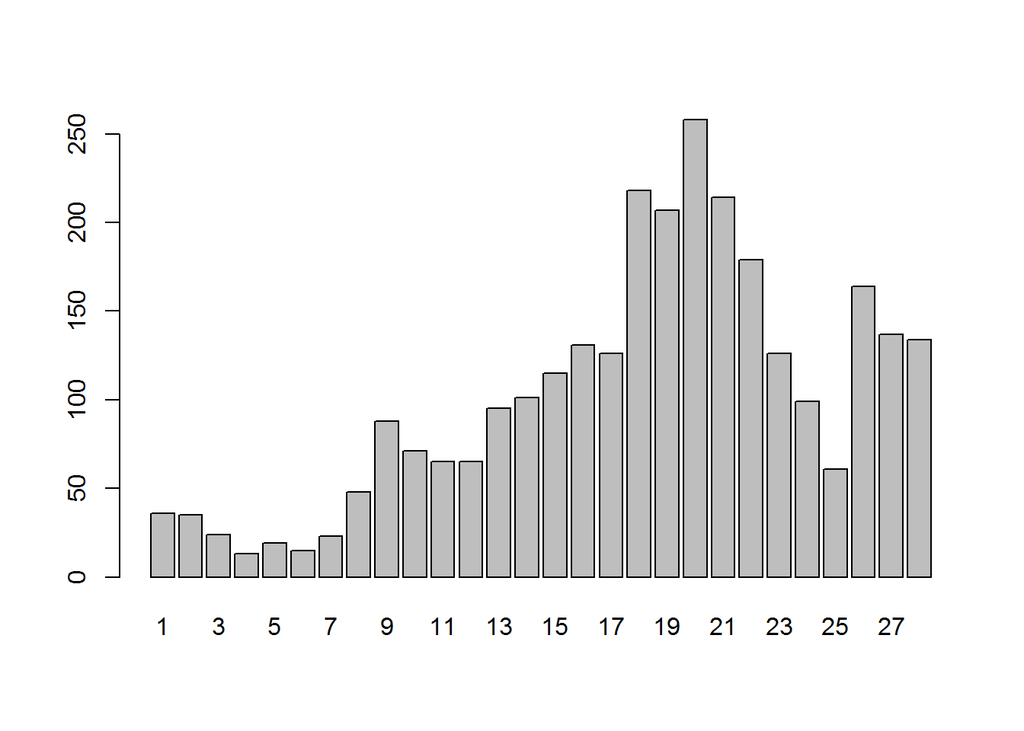

```r
# so we can recode it with `ifelse()`
dat$sex <- ifelse(dat$sex==1, "male", "female")

# income has lots of different values
# ALSO BTW YAY FIRST PLOT!
barplot(table(dat$INCOME16))
```

```r
# so we'll have to recode it in a more mechanical fashion...

# one option:
# recode income to `hi` or `mid` or `lo`, according to external values
lo  <- 1:12; mid <- 13:21; hi  <- 22:26
dat$income_cat <- ifelse(
  dat$INCOME16 %in% lo, "lo", ifelse(
    dat$INCOME16 %in% mid, "mid", ifelse(
      dat$INCOME16 %in% hi, "hi", NA
    )
  )
); rm(lo); rm(mid); rm(hi)

# another option:
# read in external vals as a table, and just sub in values for numeric codes
income <- read.csv(
  "datasets/lookup_income.csv", header=FALSE, col.names=c("num","val"),
  stringsAsFactors=FALSE
)
# **note**:
#   the following three lines won't feel intuitive right away,
#   but try to break down what's happening step by step.
#   this recoding method is very general and very useful.

# make a vector with values equal to income$val, the desired values
income_lkup        <- as.vector(income$val)

# set the names of that vector to the current values, i.e. income$num
names(income_lkup) <- income$num

# now recode income by matching the current values w the lookup table names
dat$income_range <- income_lkup[match(dat$INCOME16, names(income_lkup))]

# remove the original income col
dat$INCOME16 <- NULL
```

**note**: semicolons just “end” the current line – they’re used to put a small set of similar commands on a single line to save space and emphasize that they’re all involved in a single operation.

**note**: notice that when recoding income, we assigning the new values to the new column `income_range`, instead of the existing one, `INCOME16`. This was deliberate: if we do it this way, then we’ll (temporarily) have both columns to look at, so we can check our work by comparing the old column to the new one.

**exercise**: make a new column, derived from `income_range`, that contains the same information as `income_cat` (which was computed directly from `INCOME16`)

#### 3.3 a slightly more complicated case

```r
# let's check out the race cols again
table(dat$racecen1, useNA="always")
```

```
##
##    1    2    3    4    5    6    7    8    9   10   11   12   14   15   16
## 2088  487   58   25   19   22    7    3    4   10    1    1    2   13  103
##   98   99 <NA>
##    9   15    0
```

```r
table(dat$racecen2, useNA="always")
```

```
##
##    0    1    2    3    4    5    6    7    8    9   10   13   14   15   16
## 2617   35   24  140    1    2    3    3    3    1    4    3    3    4    8
##   98   99 <NA>
##    1   15    0
```

```r
# kinda messy...let's just extract the census's notion of "ethnicity"
# (i.e. hispanic or non-hispanic)

# first read in our associative array of keys and values
race <- read.csv(
  "datasets/lookup_race.csv", header=FALSE, col.names=c("num","val"),
  stringsAsFactors=FALSE
)
race_lkup        <- as.vector(race$val)
names(race_lkup) <- race$num

dat$racecen1 <- ifelse(dat$racecen1 %in% c(0,98,99), NA, dat$racecen1)
dat$racecen2 <- ifelse(dat$racecen2 %in% c(0,98,99), NA, dat$racecen2)

dat$racecen1 <- race_lkup[match(dat$racecen1, names(race_lkup))]
dat$racecen2 <- race_lkup[match(dat$racecen2, names(race_lkup))]

dat$hisp <- ifelse(
  dat$racecen1=="Hispanic", "hispanic", "nonhispanic"
)
dat$hisp[dat$racecen2=="Hispanic"] <- "hispanic"

# now we can safely eliminate the `racecen1/2` columns
dat$racecen1 <- NULL; dat$racecen2 <- NULL
```

**exercise**: if we wanted to investigate the effect of “race” on responses, how would/should/could we represent “race”? In other words, how many columns, what is in each column, etc. etc. What would be some benefits and drawbacks of two competing approaches?

#### 3.4 reorganize columns as desired, toss unused ones

```r
# now we have everything except the outcome vars
# reorganize the df the way we want it

# vector of the demographic columns we want to keep around
dem_cols  <- c("id", "year", "form", "sex", "age", "income_cat", "hisp")

# vector of the questionnaire items
item_cols <- names(dat)[startsWith(names(dat), "nat")]

# subsetting the data by columns, keeping just `dem_cols` and `item_cols`
dat <- dat[, c(dem_cols, item_cols)]
```

#### 3.5 creating the desired outcome variable with `reshape2::melt()`

Now we’ll implement the strategy from Section 2 above for representing the responses. This involves a process called “melting” the dataset. The result is moving from the current “wide format” to a “long format” dataset. Google around and you’ll find some nice explainers quickly.

The terminology should become more clear as you see more instances of this very common transformation.

```r
# NATFARE/NATFAREY/NATCITY/NATCITYY/NATRACE/NATRACEY
#    9        "No answer"
#    8        "Don't know"
#    3        "Too much"
#    2        "About right"
#    1        "Too little"
#    0        "Not applicable"

# `melt()` comes from the package `reshape2::`
library("reshape2")

# hold `dem_cols` (see above) constant, collapse the other columns
dat <- melt(dat, id.vars=dem_cols)

# recode the new "column-column" as character (instead of factor)
dat$variable <- as.character(dat$variable)

# rename the column-column ("variable") and the response-column ("value")
names(dat)[names(dat)=="variable"] <- "item"
names(dat)[names(dat)=="value"]    <- "response"

# check out what we have now:
knitr::kable(head(dat, n=10))
```

| id | year | form | sex | age | income_cat | hisp | item | response |
| --- | --- | --- | --- | --- | --- | --- | --- | --- |
| resp1 | 2016 | standard | male | 47 | hi | nonhispanic | natcity | 2 |
| resp2 | 2016 | standard | male | 61 | mid | nonhispanic | natcity | 8 |
| resp3 | 2016 | standard | male | 72 | mid | nonhispanic | natcity | 8 |
| resp4 | 2016 | standard | female | 43 | hi | nonhispanic | natcity | 2 |
| resp5 | 2016 | assistance | female | 55 | hi | nonhispanic | natcity | 0 |
| resp6 | 2016 | standard | female | 53 | mid | nonhispanic | natcity | 1 |
| resp7 | 2016 | standard | male | 50 | hi | nonhispanic | natcity | 2 |
| resp8 | 2016 | standard | female | 23 | mid | hispanic | natcity | 1 |
| resp9 | 2016 | standard | male | 45 | mid | nonhispanic | natcity | 2 |
| resp10 | 2016 | assistance | male | 71 | mid | nonhispanic | natcity | 0 |

**exercise**: how does the line of code renaming `variable` to `item` work? Try the command `"item" -> names(dat)[names(dat)=="variable"]`. What is the symbol `->` and how is it related to `<-`?

```r
# toss all the rows w/o real answers
# (don't forget the comma before the closing square bracked -- `dat` is a df!)
dat <- dat[!dat$response %in% c(9, 8, 0), ]

# make a lookup table for the responses
val_lkup <- c(`1`="too little", `2`="about right", `3`="too much")

# recode responses as character
dat$response <- as.character(val_lkup[match(dat$response, names(val_lkup))])

# look at a table
knitr::kable(table(dat$response, useNA="ifany"), col.names=c("resp", "freq"), pad=0)
```

| resp | freq |
| --- | --- |
| about right | 2781 |
| too little | 3516 |
| too much | 1662 |

**note**: the “backtick” syntax (` and `) allows you to use numbers, spaces, and other stuff that you wouldn’t normally be able to directly say without a syntax error. For example if you had a column of `dat` called `favorite color`, you couldn’t say `dat$favorite color` because there’s a space in the column name. But you *could* say `` dat$`favorite color` `` to refer to that column.

Recall point 3. in our gameplan above – we want just 3 unique vals in `item`. But currently we have six:

```r
knitr::kable(table(dat$item, useNA="ifany"), col.names=c("item", "freq"), pad=0)
```

| item | freq |
| --- | --- |
| natcity | 1315 |
| natcityy | 1277 |
| natfare | 1385 |
| natfarey | 1403 |
| natrace | 1294 |
| natracey | 1285 |

A simple – albeit kind of sloppy – solution would be to just remove all occurrences of the letter “y” from the `item` column. Let’s just do that (see exercise though):

```r
# for now we'll just toss all y's to make life easier
dat$item <- gsub("y", "", dat$item)

# confirm that we have just three vals now
knitr::kable(table(dat$item, useNA="ifany"), col.names=c("item", "freq"), pad=0)
```

| item | freq |
| --- | --- |
| natcit | 2592 |
| natfare | 2788 |
| natrace | 2579 |

**exercise**: what if anything could or would go wrong if we just chopped off all the `"y"`’s in the current situation? What conditions would *definitely* cause this to be a bad idea?

### 4. summarizing and plotting the data

#### 4.1 summarizing data with a variety of methods

Here’s a variety of ways we can summarize the data, using a few different strategies.

```r
# many ways to summarize data by groups!

# frequency tables
table(dat$sex, dat$response)
```

```
##
##          about right too little too much
##   female        1488       1986      886
##   male          1293       1530      776
```

```r
table(dat$income_cat, dat$response)
```

```
##
##       about right too little too much
##   hi          678        718      373
##   lo          472        658      252
##   mid        1387       1821      874
```

```r
# tables can have arbitrary dimensions, but even three is tough to parse...
# table(dat$sex, dat$income_cat, dat$response)

# cross-tabulate
xtabs( ~ sex + income_cat, data=dat)
```

```
##         income_cat
## sex        hi   lo  mid
##   female  816  779 2297
##   male    953  603 1785
```

```r
xtabs( ~ response + sex + income_cat, data=dat)
```

```
## , , income_cat = hi
##
##              sex
## response      female male
##   about right    294  384
##   too little     368  350
##   too much       154  219
##
## , , income_cat = lo
##
##              sex
## response      female male
##   about right    269  203
##   too little     386  272
##   too much       124  128
##
## , , income_cat = mid
##
##              sex
## response      female male
##   about right    769  618
##   too little    1027  794
##   too much       501  373
```

```r
# marginal proportions
# **exercise** try setting margin=2
prop.table(xtabs( ~ response + income_cat, data=dat), margin=1)
```

```
##              income_cat
## response             hi        lo       mid
##   about right 0.2672448 0.1860465 0.5467087
##   too little  0.2245855 0.2058180 0.5695965
##   too much    0.2488326 0.1681121 0.5830554
```

```r
prop.table(table(dat$response, dat$income_cat), margin=1)
```

```
##
##                      hi        lo       mid
##   about right 0.2672448 0.1860465 0.5467087
##   too little  0.2245855 0.2058180 0.5695965
##   too much    0.2488326 0.1681121 0.5830554
```

```r
# can use formula interface with `aggregate()`
aggregate(age ~ sex + income_cat, FUN="mean", data=dat)
```

```
##      sex income_cat      age
## 1 female         hi 49.33946
## 2   male         hi 49.13641
## 3 female         lo 49.44673
## 4   male         lo 48.65008
## 5 female        mid 48.68655
## 6   male        mid 48.14230
```

```r
aggregate(age ~ sex + income_cat, FUN="sd", data=dat)
```

```
##      sex income_cat      age
## 1 female         hi 14.45683
## 2   male         hi 16.25358
## 3 female         lo 19.11131
## 4   male         lo 18.48916
## 5 female        mid 18.02443
## 6   male        mid 17.39359
```

```r
aggregate(age ~ sex + income_cat, FUN=function(x) round(mean(x)), data=dat)
```

```
##      sex income_cat age
## 1 female         hi  49
## 2   male         hi  49
## 3 female         lo  49
## 4   male         lo  49
## 5 female        mid  49
## 6   male        mid  48
```

```r
# write a custom function for aggregating
custom_summary <- function(x){
  c(mean=round(mean(x)), sd=round(sd(x)), min=min(x), max=max(x))
}
aggregate(age ~ sex + income_cat, FUN=custom_summary, data=dat)
```

```
##      sex income_cat age.mean age.sd age.min age.max
## 1 female         hi       49     14      18      99
## 2   male         hi       49     16      18      99
## 3 female         lo       49     19      19      89
## 4   male         lo       49     18      18      89
## 5 female        mid       49     18      18      99
## 6   male        mid       48     17      18      99
```

```r
#


# and finally, my drug of choice is dplyr::summarize()/group_by()
library("dplyr")
dat %>% group_by(sex, income_cat) %>% summarize(
  num_obs = length(response),
  num_toolittle = sum(response=="too little", na.rm=TRUE),
  prop_toolittle  = num_toolittle / num_obs,
  num_aboutright = sum(response=="about right", na.rm=TRUE),
  prop_aboutright = num_aboutright / num_obs,
  num_toomuch = sum(response=="too much", na.rm=TRUE),
  prop_toomuch = num_toomuch / num_obs
  # the `mutate_if()` is just to make it display nicer
) %>% mutate_if(is.numeric, round, digits=3) %>% data.frame()
```

```
##      sex income_cat num_obs num_toolittle prop_toolittle num_aboutright
## 1 female         hi     816           368          0.451            294
## 2 female         lo     779           386          0.496            269
## 3 female        mid    2297          1027          0.447            769
## 4 female       <NA>     468           205          0.438            156
## 5   male         hi     953           350          0.367            384
## 6   male         lo     603           272          0.451            203
## 7   male        mid    1785           794          0.445            618
## 8   male       <NA>     258           114          0.442             88
##   prop_aboutright num_toomuch prop_toomuch
## 1           0.360         154        0.189
## 2           0.345         124        0.159
## 3           0.335         501        0.218
## 4           0.333         107        0.229
## 5           0.403         219        0.230
## 6           0.337         128        0.212
## 7           0.346         373        0.209
## 8           0.341          56        0.217
```

```r
dat %>% group_by(item, form) %>% summarize(
  num_obs = length(response),
  num_toolittle = sum(response=="too little", na.rm=TRUE),
  prop_toolittle  = num_toolittle / num_obs,
  num_aboutright = sum(response=="about right", na.rm=TRUE),
  prop_aboutright = num_aboutright / num_obs,
  num_toomuch = sum(response=="too much", na.rm=TRUE),
  prop_toomuch = num_toomuch / num_obs
) %>% mutate_if(is.numeric, round, digits=3) %>% data.frame()
```

```
##      item       form num_obs num_toolittle prop_toolittle num_aboutright
## 1  natcit assistance    1277           309          0.242            529
## 2  natcit   standard    1315           683          0.519            455
## 3 natfare assistance    1403          1002          0.714            301
## 4 natfare   standard    1385           316          0.228            477
## 5 natrace assistance    1285           534          0.416            535
## 6 natrace   standard    1294           672          0.519            484
##   prop_aboutright num_toomuch prop_toomuch
## 1           0.414         439        0.344
## 2           0.346         177        0.135
## 3           0.215         100        0.071
## 4           0.344         592        0.427
## 5           0.416         216        0.168
## 6           0.374         138        0.107
```

**exercise**: what does the following command yield, and why does it yield that? Does this make sense as a summary for some combination of our variables? command: `xtabs(age ~ sex + income_cat, data=dat)`

**note**: you’ll see the *formula* interface used in `xtabs()` in a few different areas in R – most notably in regression modeling. The form is usually `y ~ x1 + ... + xn`, with `y` being the outcome variable and the `xi`’s being predictors.

Now let’s get to plotting folks!!!

#### 4.2 plotting with base functions

There are several base functions for making plots. They’re great for exploratory analysis because they’re so quick and easy. They can be customized endlessly, but if you want to customize the appearance, you’re better off using `ggplot()`.

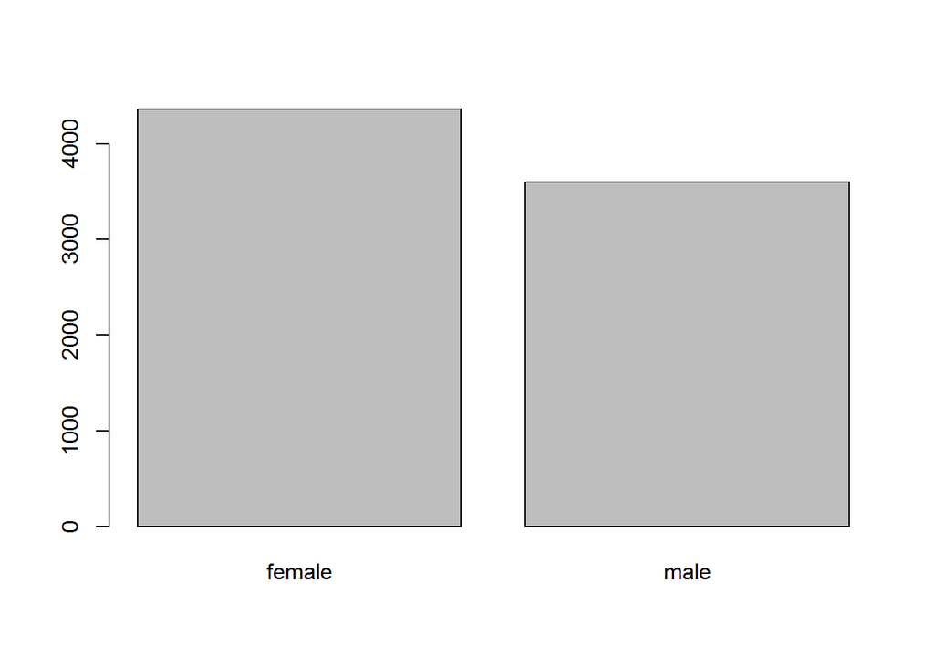

```r
# barplots made from a table
barplot(table(dat$sex))
```

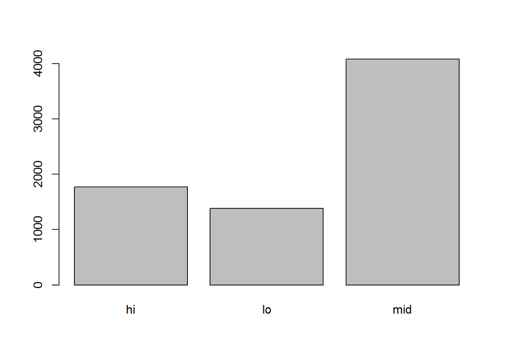

```r
barplot(table(dat$income_cat))
```

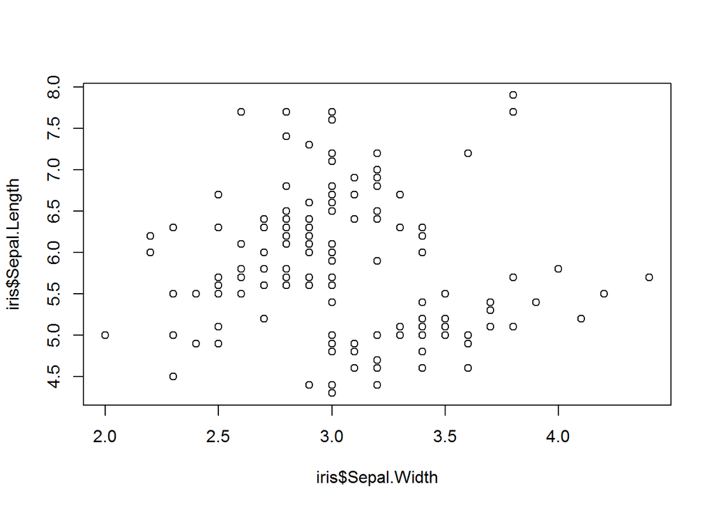

```r
# basic scatterplot
plot(iris$Sepal.Width, iris$Sepal.Length)
```

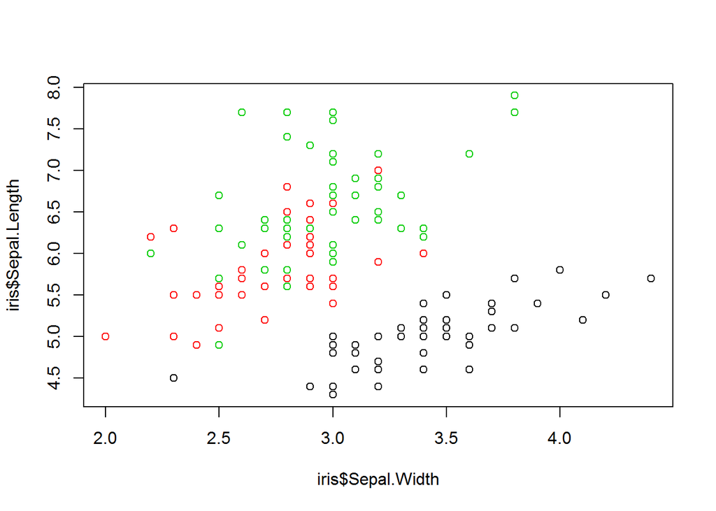

```r
# with color coding
plot(iris$Sepal.Width, iris$Sepal.Length, col=iris$Species)
```

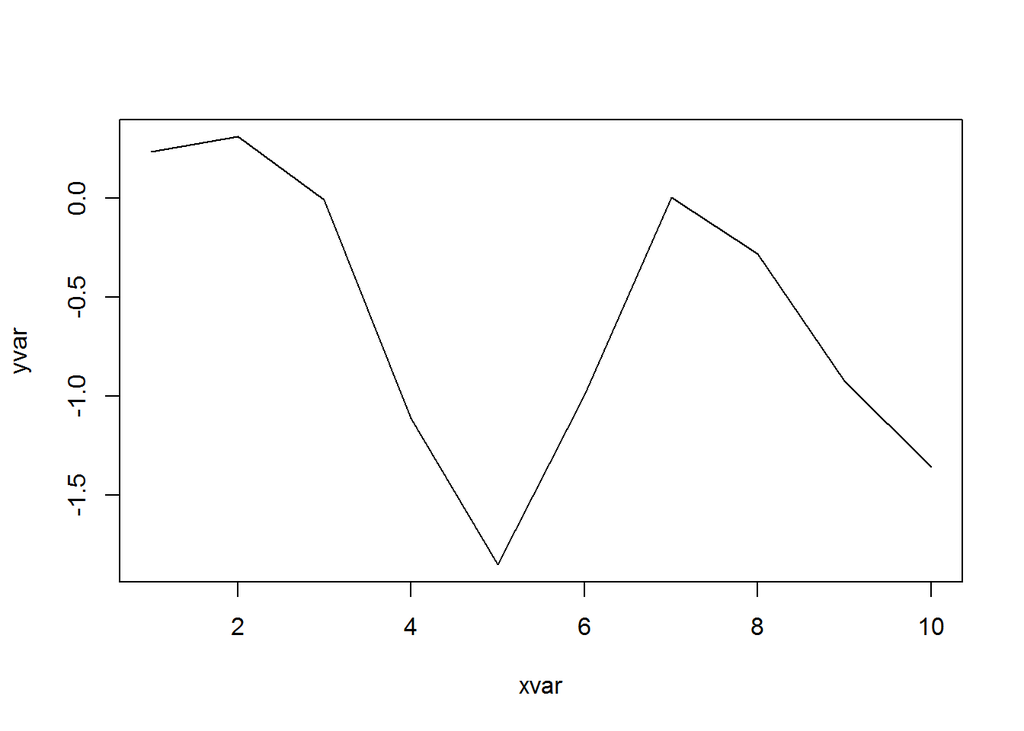

```r
xvar <- 1:10
yvar <- rnorm(xvar)
# line plot (nice for time-series)
plot(xvar, yvar, type="l")
```

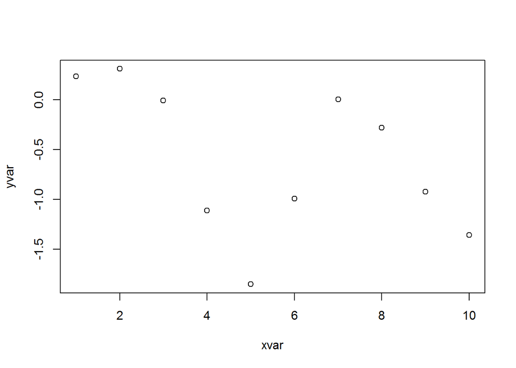

```r
# scatter
plot(xvar, yvar, type="p")
```

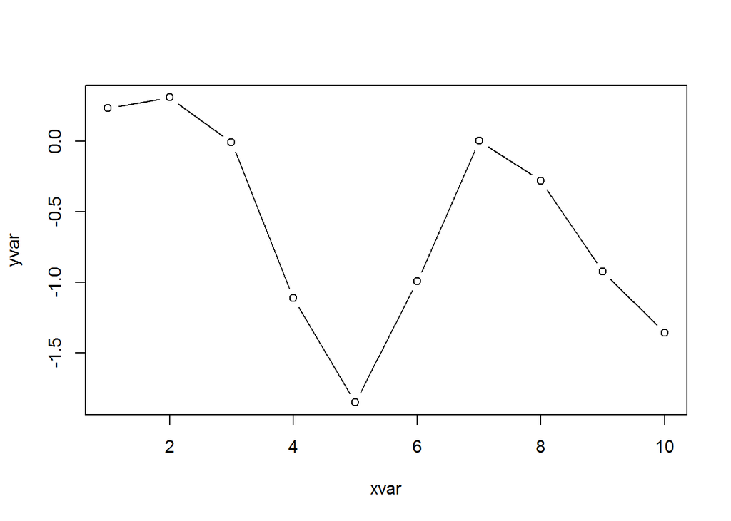

```r
# both
plot(xvar, yvar, type="b")
```

```r
# other options are "c", "o", "S"/"s", "h", "n"
```

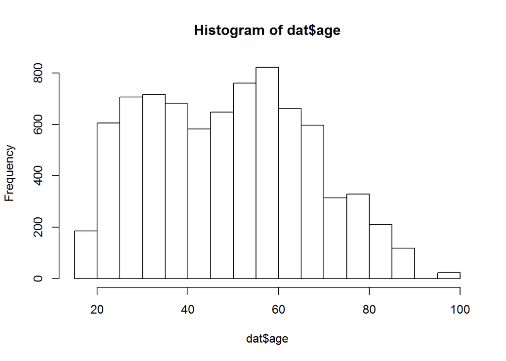

```r
# histograms for numeric univariate distributions
# this is probably the base plotting function i use the most
hist(dat$age)
```

**exercise**: merge the 2012, 2014, and 2016 data using a `*_join()` operation from `dplyr::` (see the top-right of the second page of the data wrangling cheatsheet). Then make a line-plot where the x-axis is `year`, and the y-axis is proportion “too much” responses across all three items.

**exercise**: after doing the previous exercise, read in the file called `"datasets/gss_complete_test.csv"` and make the corresponding plot. Does it look identical to yours? (*hint*: it should!)